# Implementação e Análise de Algoritmos de Ordenação

- Questão 1 - Implemente em uma linguagem de programação a sua escolha o algoritmo de ordenação QuickSort com o pivô sendo o elemento do meio. Em seguida, trabalhe os itens abaixo.
  - A - Sequência aleatória de números entre 1 e 100.
  - B - Qual a complexidade no tempo do algoritmo?
  - C - Comparar -> Sequencia Aleatória x Ordenada (Cresc/Decre).
  - D - Algoritmo modificado: Pivô aleatório.
  - E - Pivô no meio x Pivô aletório, nas duas situações.
- Questão 2 - Implemente em uma linguagem de programação a sua escolha o algoritmo de ordenação HeapSort. Em seguida, trabalhe os itens abaixo.
  - A - Use uma sequência aleatória de números inteiros entre 1 e 100 como entrada do algoritmo e apresente o print da execução.
  - B - Qual é a complexidade no tempo do algoritmo? Explique.
  - C -
    - c1 - Compare o tempo de execução do algoritmo quando o mesmo recebe como entrada sequências ordenadas em ordem crescente e decrescente e desordenadas.
    - c2 - Caso mais números fossem inseridos nas sequências, como o desempenho do algoritmo seria afetado? Usando dados reais, ilustre graficamente suas conclusões.
  - D - Faça um estudo comparativo do algoritmo HeapSort com os algoritmos QuickSort, implementados na Questão 1, nas situações apresentadas.
- Questão 3 - Implemente em uma linguagem de programação a sua escolha os algoritmos de ordenação linear CountingSort e BucketSort. Em seguida, trabalhe os itens abaixo.
  - A - Analise o comportamento do tempo de execução do algoritmo CountingSort quando o número de elementos da sequência de entrada é aumentado gradativamente. Durante a análise, comente a relação que existe entre o tamanho da sequência de entrada e o elemento de maior valor nessa sequência. Usando dados reais, ilustre graficamente suas conclusões.
  - B - Compare o tempo de execução do algoritmo BucketSort quando o mesmo recebe como entrada sequências uniformemente distribuídas. Caso mais números fossem inseridos nas sequências, como o desempenho do algoritmo seria afetado? Usando dados reais, ilustre graficamente suas conclusões.
- Questão 4 - Compare o tempo de execução dos algoritmos CountingSort e QuickSort em situações reais de uso. Explique qual algoritmo é mais eficiente e por que.
  - Plotando tempos para vetores de 1K a 10K elementos.
  - Plotando tempos para vetores de 10K a 100K elementos.
  - Conclusões

### Integrantes:

João Canavarro  
Renan Cunha  
Ronaldd Pinho  
Wagner Felidré

## Questão 1 - Implemente em uma linguagem de programação a sua escolha o algoritmo de ordenação QuickSort com o pivô sendo o elemento do meio. Em seguida, trabalhe os itens abaixo.

### A - Sequência aleatória de números entre 1 e 100.

```python
print("100 Elementos -> Pivô no meio.\n")

x = [random.randint(1,100) for l in range (100)]

print("Lista x Desordenada:",x)
print("Lista x Ordenada:",quick_sort(x))
```

```
100 Elementos -> Pivô no meio.

Lista x Desordenada: [5, 73, 40, 8, 56, 43, 17, 14, 50, 33, 33, 90, 9, 6, 98, 55, 72, 23, 32, 33, 20, 77, 85, 9, 25, 26, 26, 28, 37, 64, 15, 83, 78, 6, 13, 99, 72, 88, 46, 27, 77, 4, 65, 56, 55, 58, 12, 85, 58, 59, 19, 7, 45, 70, 73, 50, 29, 74, 88, 62, 25, 4, 59, 91, 3, 95, 38, 52, 92, 94, 97, 91, …
Lista x Ordenada: [2, 3, 4, 4, 4, 5, 6, 6, 6, 6, 7, 12, 13, 13, 15, 15, 15, 15, 17, 18, 19, 19, 21, 25, 26, 26, 26, 26, 27, 27, 28, 29, 29, 31, 34, 36, 36, 37, 38, 38, 38, 45, 45, 45, 45, 46, 50, 50, 52, 52, 53, 54, 54, 55, 56, 58, 58, 58, 59, 59, 59, 62, 62, 66, 69, 70, 70, 70, 72, 73, 73, 74, 74, …
```

### B - Qual a complexidade no tempo do algoritmo?

Sua complexidade no melhor caso é O(nlog2(n)) e no pior caso é O(n²). O pior caso ocorre quando o pivô é o maior ou menor elemento do sub-problema. Escolhemos o pivô aleatoriamente para obter bom desempenho no caso médio sobre todas as entradas.

### C - Comparar -> Sequencia Aleatória x Ordenada Cresc/Decre.

```
->Pivô no meio.

Média Desordenado 1 000 - 20 000 elem.: 1.11980310676
Média Crescente 1 000 - 20 000 elem.: 0.7736880974
Média Decrescente 1 000 - 20 000 elem.: 0.832242755344
```

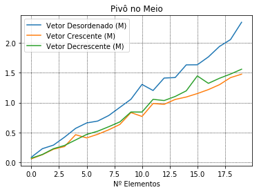

```python
print("->Pivô no meio.\n")
tx = []
tcresc = []
tdecre = []
i = 1000

while (i <= 20000):
    x = [random.randint(1,i)for l in range (i)]
    cresc = [l for l in range (i)]
    decre = [l for l in range(i-1, -1, -1)]

    #Desordenado
    tx.append(timeit.timeit(lambda:quick_sort(x),number = 40))
    #Crescente
    tcresc.append(timeit.timeit(lambda:quick_sort(cresc),number = 40))
    #Decrescente
    tdecre.append(timeit.timeit(lambda:quick_sort(decre),number = 40))
    i+=1000

print("Média Desordenado 1 000 - 20 000 elem.:",np.mean(tx))
print("Média Crescente 1 000 - 20 000 elem.:",np.mean(tcresc))
print("Média Decrescente 1 000 - 20 000 elem.:",np.mean(tdecre))

num_elementos = np.arange(len(tx))

plt.plot(num_elementos,tx,label = 'Vetor Desordenado (M)')
plt.plot(num_elementos,tcresc,label = 'Vetor Crescente (M)')
plt.plot(num_elementos,tdecre,label = 'Vetor Decrescente (M)')

plt.legend()
plt.title("Pivô no Meio")
plt.xlabel("Nº Elementos")
plt.grid(linestyle = ':', color = 'k')
plt.show()
```

### D - Algoritmo modificado: Pivô aleatório.

```
--------------------------
100 Elementos -> Pivô aleatório.

Lista x Desornada: [50, 81, 24, 15, 44, 97, 72, 39, 58, 38, 27, 89, 28, 67, 9, 69, 40, 81, 43, 46, 100, 54, 39, 71, 37, 78, 1, 11, 63, 76, 91, 16, 15, 50, 10, 42, 14, 60, 24, 29, 55, 17, 45, 36, 11, 66, 19, 81, 97, 9, 16, 3, 52, 51, 61, 36, 55, 20, 71, 74, 94, 46, 83, 89, 24, 55, 65, 38, 66, 24, 76,…
Lista x Ordenada: [3, 9, 9, 9, 10, 10, 11, 11, 11, 12, 12, 13, 14, 15, 16, 16, 17, 18, 19, 19, 19, 20, 20, 24, 24, 24, 24, 26, 30, 30, 30, 33, 34, 36, 36, 36, 37, 37, 38, 42, 42, 43, 46, 46, 46, 46, 51, 51, 51, 51, 51, 51, 51, 51, 52, 52, 55, 55, 55, 55, 60, 61, 61, 63, 63, 65, 65, 66, 66, 66, 68, 7…

--------------------------

->Pivô aleatório.

Média Desordenado 1 000 - 20 000 elem.: 1.10925146763
Média Crescente 1 000 - 20 000 elem.: 0.767213877434
Média Decrescente 1 000 - 20 000 elem.: 0.833393942679
```

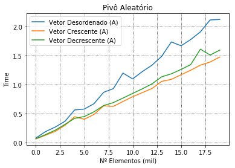

```python
print("\n--------------------------")
print("100 Elementos -> Pivô aleatório.\n")

x = [random.randint(1,100) for l in range (100)]

print("Lista x Desornada:",x)
print("Lista x Ordenada:",quick_sort_modificado(x))

print("\n--------------------------\n")

print("->Pivô aleatório.\n")

tx_mod = []
tcresc_mod = []
tdecre_mod = []

i = 1000
while (i <= 20000):
  x_mod = [random.randint(1,i) for l in range (i)]
  cresc_mod = [l for l in range (i)]
  decre_mod = [l for l in range(i, 0, -1)]

  #Desordenado Modificado
  tx_mod.append(timeit.timeit(lambda:quick_sort_modificado(x_mod),number = 40))
  #"Crescente Modificado
  tcresc_mod.append(timeit.timeit(lambda:quick_sort_modificado(cresc_mod),number = 40))
  #Decrescente Modificado
  tdecre_mod.append(timeit.timeit(lambda:quick_sort_modificado(decre_mod),number = 40))
  i+=1000

print("Média Desordenado 1 000 - 20 000 elem.:",np.mean(tx_mod))
print("Média Crescente 1 000 - 20 000 elem.:",np.mean(tcresc_mod))
print("Média Decrescente 1 000 - 20 000 elem.:",np.mean(tdecre_mod))

plt.plot(num_elementos,tx_mod,label = 'Vetor Desordenado (A)')
plt.plot(num_elementos,tcresc_mod,label = 'Vetor Crescente (A)')
plt.plot(num_elementos,tdecre_mod,label = 'Vetor Decrescente (A)')
plt.legend()
plt.title("Pivô Aleatório")
plt.ylabel("Time")
plt.xlabel("Nº Elementos (mil)")
plt.grid(linestyle = ':', color = 'k')

plt.show()
```

### E - Pivô no meio x Pivô aletório, nas duas situações.

A escolha do pivô é crucial para o bom desempenho do método, já que a fase de partição é a parte crítica do algoritmo. Intuitivamente o pivô no meio pode parecer uma boa escolha, mas em alguns casos não funciona bem, levando o algoritmo a complexidade quadrática. Desse modo, quando não sabemos como os elementos estão arranjados, podemos adicionar um fator de aleatoriedade na escolha do pivô. Analisando os resultados dos dois algoritmos, principalmente nos de 20 000 execuções, percebemos uma diferença consideravel entre o a ordenação de vetores com valores aleatoriamente distribuidos, e os vetores ordenados crescentes e decrescentes.

## Questão 2 - Implemente em uma linguagem de programação a sua escolha o algoritmo de ordenação HeapSort. Em seguida, trabalhe os itens abaixo.

### A - Use uma sequência aleatória de números inteiros entre 1 e 100 como entrada do algoritmo e apresente o print da execução.

```python
tamanho = random.randint(1, 100)
unsorted = np.random.randint(tamanho, size = tamanho)  #Generate 100 elements
print('vetor não ordenado\n', unsorted)
print('vetor ordenado \n', heap_sort(unsorted))
```

```
vetor não ordenado
 [43 22 11 69 34 19 57 18 54 82 51 16 80 44 29 52  0 56 80 78 14  2 17 81
 33 82 48 17 56 63 63 75 43 70 74 70 71 59 73 48 76 66 28 81 53 18 62 24
 35 15 59 65 16  7 34 24 44 17 31 16 24 82 24 44 35 57 62 14 74 15 37 76
 81  3  2 18 10 36 45  4 43 53 77 24]
vetor ordenado
 [ 0  2  2  3  4  7 10 11 14 14 15 15 16 16 16 17 17 17 18 18 18 19 22 24
 24 24 24 24 28 29 31 33 34 34 35 35 36 37 43 43 43 44 44 44 45 48 48 51
 52 53 53 54 56 56 57 57 59 59 62 62 63 63 65 66 69 70 70 71 73 74 74 75
 76 76 77 78 80 80 81 81 81 82 82 82]
```

### B - Qual é a complexidade no tempo do algoritmo? Explique.

O algoritmo heapSort tem por sua complexidade no melhor caso n*log(n) e para o pior caso n*log(n), porém deve constar que a quantidade de trocas realizadas influenciam na eficiência do algoritmo, sendo assim um vetor decrescente possuiria um desempenho em tempo relativamente melhor que um vetor em ordem crescente, sendo estes dados como entrada para a ordenação.

### c1 - Compare o tempo de execução do algoritmo quando o mesmo recebe como entrada sequências ordenadas em ordem crescente e decrescente e desordenadas.

### c2 - Caso mais números fossem inseridos nas sequências, como o desempenho do algoritmo seria afetado? Usando dados reais, ilustre graficamente suas conclusões.

```
[ 10  20  30  40  50  60  70  80  90 100]
```

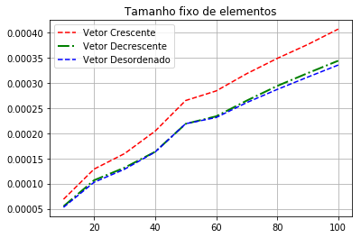

```
[ 10000  20000  30000  40000  50000  60000  70000  80000  90000 100000]
```

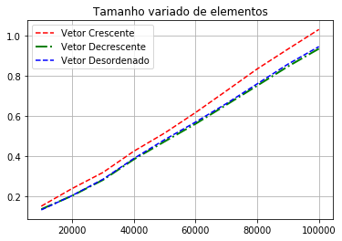

```python
tamanho, tempo_crescente, tempo_decrescente, tempo_desordenado = ordenacoes(1)
plotagem_tempo(0, tamanho, tempo_crescente, tempo_decrescente, tempo_desordenado)

tamanho, tempo_crescente, tempo_decrescente, tempo_desordenado = ordenacoes(0)
plotagem_tempo(1, tamanho, tempo_crescente, tempo_decrescente, tempo_desordenado)
```

A ordenação ocorre para o caso (C1) com valores de 1 a 100, para o caso (C2) ocorre com valores de 1 a 100.000, conforme fica evidenciado acima.

C1) Sendo assim para um vetor em ordem crescente possui mais etapas de trocas realizadas desta forma possui um tempo mais elevado que os vetor aleatórios ou decrescentes, os vetores descrescentes e aleatórios possuem tempo relativamente próximo, visto que um vetor decrescente precisa fazer menos iterações de troca e o vetor aleatório dependendo da situação dos elementos do vetor pode obter quase a mesma quatidade de iterações.

C2) Para o segundo caso, como foi constatado o vetor em ordem crescente à ser ordenado será mais oneroso que vetores decrescente e desordenado, porém para valores pequenos os vetores decrescente e aleatório possuem tempo próximos, porém para valores assintóticos o vetor aleatório possui pior desenpenho, visto que há a possibilidade de fazer menos iterações que o vetor descrescente.

### D - Faça um estudo comparativo do algoritmo HeapSort com os algoritmos QuickSort, implementados na Questão 1, nas situações apresentadas.

Para o quick sort o pior caso de particionamento ocorre quando o elemento pivô divide a lista de forma desbalanceada, ou seja, divide a lista em duas sub listas: uma com tamanho 0 e outra com tamanho n - 1, sendo assim possuindo complexidade (n²), contrapartida o heap sort não é influenciado em complexidade com o tipo de entradada do vetor, este possui complexidade de nlog(n) para o pior caso.

O melhor caso de particionamento do quick sort acontece quando ele produz duas listas de tamanho não maior que n/2, assim possuindo complexidade nlog(n), o heap sort no seu melhor caso também possui complexidade nlog(n), pois o vetor de entrada não influencia sua complexidade.

## Questão 3 - Implemente em uma linguagem de programação a sua escolha os algoritmos de ordenação linear CountingSort e BucketSort. Em seguida, trabalhe os itens abaixo.

### A - Analise o comportamento do tempo de execução do algoritmo CountingSort quando o número de elementos da sequência de entrada é aumentado gradativamente. Durante a análise, comente a relação que existe entre o tamanho da sequência de entrada e o elemento de maior valor nessa sequência. Usando dados reais, ilustre graficamente suas conclusões.

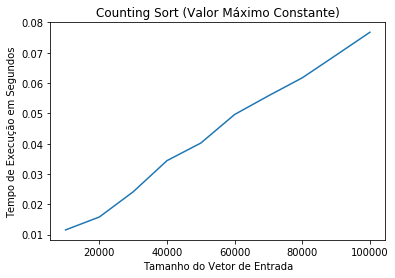

```python
x, time =  test_arrays(counting_sort, iterations=8, constant_high=True)
plot_graph(x=x,y=time,title='Counting Sort (Valor Máximo Constante)',
           label_x="Tamanho do Vetor de Entrada", label_y="Tempo de Execução em Segundos")
```

O tempo de execução do Counting Sort cresce linearmente de acordo com o tamanho do vetor de entrada

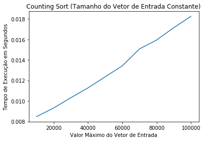

```python
x, time = test_arrays(counting_sort, iterations=8, constant_size=True)
plot_graph(x=x, y=time, title='Counting Sort (Tamanho do Vetor de Entrada Constante)',
           label_x="Valor Máximo do Vetor de Entrada", label_y="Tempo de Execução em Segundos")
```

O tempo de execução do Counting Sort cresce linearmente de acordo com o valor máximo do vetor

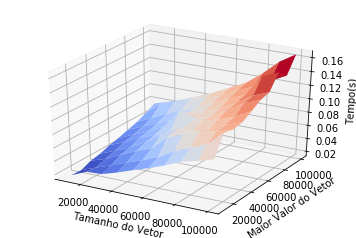

```python
X = np.resize(np.linspace(10**4, 10**5,10,dtype=int), (10,10))
Y = X.transpose(1,0)
Z = np.zeros((10,10))
for i in range(10):
    for j in range(10):
        vetor = np.random.randint(low=0, high = Y[i,j]*4, size = X[i,j])
        Z[i,j] = counting_sort(vetor)[1]
from mpl_toolkits.mplot3d import Axes3D
from matplotlib import cm

fig = plt.figure()
ax = fig.gca(projection='3d')

ax.plot_surface(X, Y, Z, cmap = cm.coolwarm)
ax.set_xlabel("Tamanho do Vetor")
ax.set_ylabel("Maior Valor do Vetor")
ax.set_zlabel("Tempo(s)")
plt.show()
```

A partir dos gráficos, é possível confirmar a complexidade temporal do Counting Sort de O(n+k), sendo 'n' o tamanho do vetor de entrada e 'k' o valor máximo do vetor. O tempo de execução do algoritmo aumenta linearmente de acordo tanto com o tamanho do vetor como com o valor máximo do vetor.

### B - Compare o tempo de execução do algoritmo BucketSort quando o mesmo recebe como entrada sequências uniformemente distribuídas. Caso mais números fossem inseridos nas sequências, como o desempenho do algoritmo seria afetado? Usando dados reais, ilustre graficamente suas conclusões.

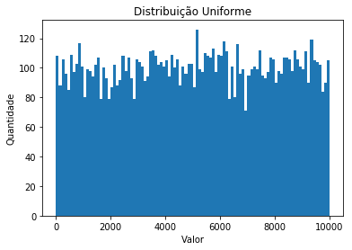

```python
numbers = np.random.uniform(0,10**4,10**4)
plot_graph(numbers, hist=True, title="Distribuição Uniforme",
              label_x="Valor", label_y="Quantidade")
```

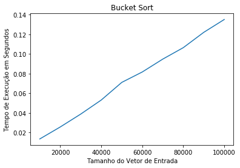

```python
x,time =  test_arrays(bucket_sort, iterations=3)
plot_graph(time,x=x, title="Bucket Sort", label_x="Tamanho do Vetor de Entrada",
           label_y="Tempo de Execução em Segundos")
```

A complexidade no tempo do algoritmo Bucket Sort é linear, então o tempo de execução vai aumentar proporcionalmente conforme o o tamanho do vetor de entrada para uma entrada.

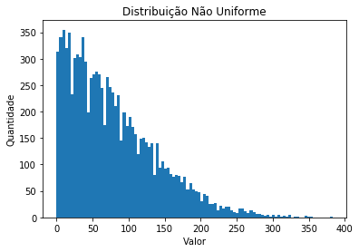

```python
numbers = abs(np.random.normal(scale=100, size=10**4).astype(int))
plot_graph(numbers, hist=True, label_x="Valor", label_y="Quantidade",
           title="Distribuição Não Uniforme")
```

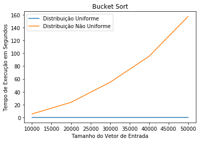

```python
x, time_pareto = test_arrays(bucket_sort, end=60000, iterations=1, uniform_dist=False)
plt.plot(x,time[:5], label="Distribuição Uniforme")
plt.plot(x,time_pareto, label="Distribuição Não Uniforme")
plt.xlabel("Tamanho do Vetor de Entrada")
plt.ylabel("Tempo de Execução em Segundos")
plt.title("Bucket Sort")
plt.legend()
plt.show()
```

Através dos gŕaficos, podemos perceber que o algoritmo Bucket Sort é muito mais eficiente para vetores de entrada que possuem seus valores distribuidos de forma uniforme.

## Questão 4 - Compare o tempo de execução dos algoritmos CountingSort e QuickSort em situações reais de uso. Explique qual algoritmo é mais eficiente e por que.

### Plotando tempos para vetores de 1K a 10K elementos.

1 - Com valores contidos no intervalo de 0 a 100.

2 - Com valores contidos no intervalo de 0 a 1000.

```
Plotando gráficos para os seguintes tamanhos:
 [ 1000  2000  3000  4000  5000  6000  7000  8000  9000 10000]

Números de 0 a 100
```

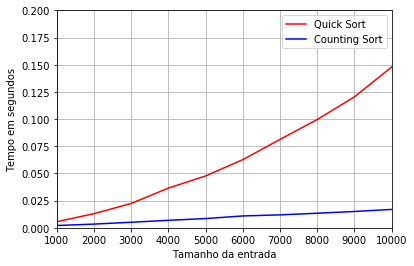

```
Números de 0 a 1000
```

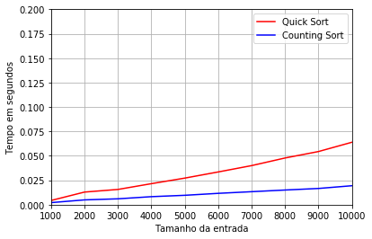

```python
# tamVetor é um vetor com os valores que serão usados como tamanho da entrada
# tamVetor = np.array([500, 600, 700, 800, 900, 1000, 1500])

tamanhos = np.arange(0, 10000 +1, 1000)[1::]

print("Plotando gráficos para os seguintes tamanhos:\n", tamanhos, "\n")

plotToInputLens(tamanhos, RANGE=100)
plt.ylim([0,.2])
plt.legend()
plt.show()

plotToInputLens(tamanhos, RANGE=1000)
plt.ylim([0,.2])
plt.legend()
plt.show()
```

OBS: Conforme aumentamos o Range, ou seja, o intervalo onde os elementos do vetor estão contidos, percebemos uma aproximação do gráfico do Quick Sort em relação ao do Counting Sort.</i>

### Plotando tempos para vetores de 10K a 100K elementos.

1 - Com valores contidos no intervalo de 0 a 100.

2 - Com valores contidos no intervalo de 0 a 1000.

3 - Com valores contidos no intervalo de 0 a 10000.

```
Plotando gráficos para os seguintes tamanhos:
 [ 10000  20000  30000  40000  50000  60000  70000  80000  90000 100000]

Números de 0 a 100
```

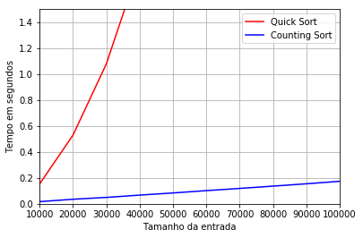

```
Números de 0 a 1000
```

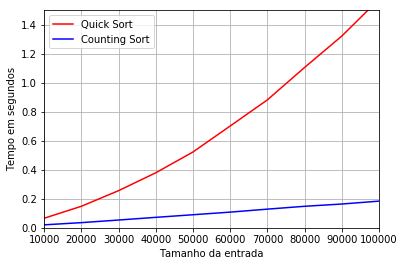

```
Números de 0 a 10000
```

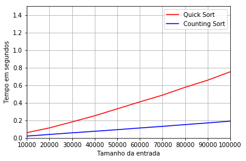

```python
tamanhos = np.arange(0, 100000+1, 10000)[1::]

print("Plotando gráficos para os seguintes tamanhos:\n", tamanhos, "\n")

plotToInputLens(tamanhos, 100) # range = CEM
plt.ylim([0 , 1.5])
plt.legend()
plt.show()

plotToInputLens(tamanhos, 1000) # Range= MIL
plt.ylim([0 , 1.5])
plt.legend()
plt.show()

plotToInputLens(tamanhos, 10000) # Range= DEZ MIL
plt.ylim([0 , 1.5])
plt.legend()
plt.show()
```

### Conclusões

Em termos de tempo de execução, o Counting Sort é mais eficiente que o Quick Sort por muitos motivos:  
O mais importante é que o Counting trabalha diretamente com os índices onde os valores devem ser colocados na versão ordenada do vetor, e apesar de as vezes utilizar muita memória auxiliar para isso, ele simplesmente conta os elementos e os posiciona corretamente em um novo vetor.

O CountingSort não depende exclusivamente do tamanho (n) do vetor de entrada, o intervalo (k) de valores que os elementos podem assumir também influencia no desempenho do Counting pois o mesmo cria um vetor auxiliar com o tamanho desse intervalo e preenche o mesmo afim de contar quantos elementos de cada valor desse intervalo existem dentro do vetor, e em seguida percorre novamente o mesmo vetor fazendo operações de soma. Portanto, o tamanho 'k' desse intervalo pode ter um peso significativo principalmente para valores assintóticos de k e n.

Percebemos nos gráficos, que o intervalo de valores também tem uma influência no desempenho do QuickSort. Isso acontece porque o Quick é um algoritmo de ordenação instável, ou seja, troca a posição relativa de valores idênticos. O seu desempenho aumenta conforme o intervalo é maior porque quanto menor esse intervalo maiores são as chances de aparecerem valores repetidos no vetor, logo, maior será o número de comparações entre valores iguais.